# Capsule 6 - Produire un mini-rapport Quarto

MQT-2101 - Analyse et modélisation des données

## Pourquoi ça compte

Une décision concrète

Le bouton Render peut-il refaire toute votre analyse à partir du fichier CSV?

Le `.qmd` doit contenir tous les packages, importations et calculs nécessaires. Pour reprendre l’analyse ailleurs, il faut aussi partager les données et disposer des logiciels et packages compatibles.

## Objectifs de la capsule

- Créer un graphique simple avec `ggplot2`.
- Structurer un mini-rapport Quarto et le rendre en HTML.
- Formuler deux constats descriptifs et une question à approfondir.

## Assembler le document dans RStudio

1. Ouvrez `rapport_semaine_02.qmd`, créé à la capsule 3.
2. Conservez l’importation et les calculs des capsules 4 et 5, dans l’ordre.
3. Ajoutez les sections, le graphique et les phrases d’interprétation.
4. Vérifiez que les appels à `library()` figurent au début du document.

Le code R va dans les blocs de code; vos explications vont à l’extérieur des blocs.

## Créer un graphique

```r
graphique_ventes <- resume_succursales |>
  mutate(succursale = fct_reorder(succursale, ventes_totales)) |>
  ggplot(aes(x = ventes_totales, y = succursale)) +
  geom_col(fill = "#0B4F6C") +
  scale_x_continuous(labels = scales::label_dollar(
    prefix = "", suffix = " $", big.mark = " ", decimal.mark = ","
  )) +
  labs(
    title = "Ventes totales par succursale",
    x = "Ventes totales ($ CA)",
    y = NULL
  ) +
  theme_minimal(base_size = 14)

graphique_ventes
```

## Le graphique obtenu

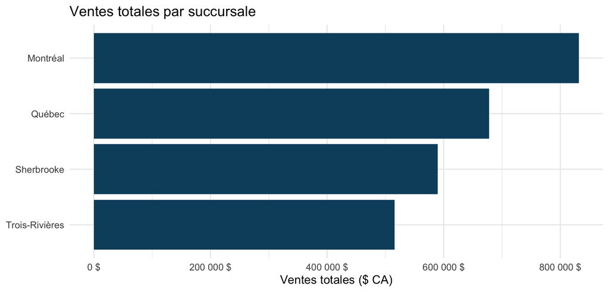

## Un graphique doit être lisible

- le titre indique ce qui est comparé;
- les axes indiquent les unités;
- les catégories sont lisibles;
- le graphique répond à une question simple.

## Structure minimale du QMD

```
---
title: "Mini-rapport - Module 2"
format:
  html:
    embed-resources: true
---

## Introduction
## Importation
## Inspection et diagnostic
## Résumé descriptif
## Graphique
## Constats
```

## Rendre le document

Dans RStudio, le bouton Render produit la page HTML du rapport.

1. Enregistrez le `.qmd`, puis cliquez sur Render.
2. Si une erreur survient, corrigez le premier bloc qui échoue.
3. Cliquez de nouveau sur Render après la correction.

Après le rendu, ouvrez le fichier HTML et vérifiez que le texte, les tableaux, le graphique et les constats apparaissent correctement.

## Écrire un constat, éviter une cause

Constat descriptif

De janvier à juin 2025, Montréal a les ventes totales les plus élevées; Sherbrooke a le panier moyen le plus élevé.

À éviter

« La campagne locale cause des ventes plus élevées » : cette analyse ne permet qu’une description.

## Question à approfondir

Les mois avec une campagne locale présentent-ils des ventes plus élevées au sein d’une même succursale?

La dernière phrase du rapport ouvre vers une analyse future : c’est le pont vers la régression.

## À retenir

1

Render doit recalculer le rapport sans commandes préalables dans la Console.

2

Le code et les résultats restent ensemble.

3

Les constats restent descriptifs; la question finale prépare la suite.

## Production autonome 2.6

Produisez le mini-rapport Quarto et vérifiez qu’il se rend sans erreur.

Avant de conclure, relisez le code d’importation, le diagnostic, le tableau, le graphique, les deux constats et la question à approfondir.

### Auto-vérification

- Le bouton Render produit le HTML sans erreur.
- Les packages et les données sont chargés dans le `.qmd`.
- Le HTML contient le diagnostic, le tableau, le graphique et mes constats.